# Содержание

### Это pet-project, в котором Вы можете увидеть, как я обрабатываю данные, визуализирую их и делаю по ним выводы. Ниже описание проекта. Шаги по выполнению проекта были предоставлены внутри самого проекта.

Вы работаете в интернет-магазине «Стримчик», который продаёт по всему миру компьютерные игры. Из открытых источников доступны исторические данные о продажах игр, оценки пользователей и экспертов, жанры и платформы (например, Xbox или PlayStation). Вам нужно выявить определяющие успешность игры закономерности. Это позволит сделать ставку на потенциально популярный продукт и спланировать рекламные кампании.  
Перед вами данные до 2016 года. Представим, что сейчас декабрь 2016 г., и вы планируете кампанию на 2017-й. Нужно отработать принцип работы с данными. Неважно, прогнозируете ли вы продажи на 2017 год по данным 2016-го или же 2027-й — по данным 2026 года.  
В наборе данных попадается аббревиатура ESRB (Entertainment Software Rating Board) — это ассоциация, определяющая возрастной рейтинг компьютерных игр. ESRB оценивает игровой контент и присваивает ему подходящую возрастную категорию, например, «Для взрослых», «Для детей младшего возраста» или «Для подростков».

```python
import pandas as pd
import numpy as np
import matplotlib
import matplotlib.pyplot as plt
import matplotlib.axes as axs
import warnings
from datetime import datetime as dt
import math
from matplotlib import transforms, pyplot as plt
from scipy import stats as st
from cycler import cycler

%matplotlib inline

#%matplotlib

pd.options.display.float_format ='{:.2f}'.format
pd.options.display.max_columns = 300
pd.options.display.max_rows = 20
warnings.filterwarnings('ignore')
```

Здесь задаю параметры постройки графиков по умолчанию, чтобы сократить код постройки нормальных графиков

```python
gray_dark = '#646369'
blue_dark = '#36608a'
blue_light = '#8aa6c2'
gray_light = '#A6A6A5'
cycle = cycler('color', [blue_dark, gray_dark, blue_light, gray_light])

plt.rc('figure', figsize=(16,10), titlesize=30, titleweight='bold')
plt.rc('axes', titlesize=26, titlelocation='left', grid=False, edgecolor=gray_dark, titley=1.02, labelpad=6, prop_cycle=cycle)
plt.rc('axes.spines', left=True, bottom=True, top=False, right=False)
plt.rc('axes.grid', axis='y')
plt.rc('text', color=gray_dark)
plt.rc('font', family='Times New Roman')
plt.rc('mathtext', fontset='custom', bf='Times New Roman:bold', it='Times New Roman:italic')
plt.rc('yaxis', labellocation='top')
plt.rc('xaxis', labellocation='right')
plt.rc('xtick', labelcolor=gray_dark, color=gray_dark, labelsize=20)
plt.rc('ytick', labelcolor=gray_dark, color=gray_dark, labelsize=20)
plt.rc('legend', edgecolor='white', title_fontsize=18)
```

Можно написать фунцию по постройке нормальных графиков, если не ууказываем по-умолчанию кастомные параметры

```python
# напишем функцию для постройки графиков

def create_line (graph_x, lines, gap, colors, titles, y_name,  line_names, result, year, data_source):

    # определяем цвета, которые будем использовать
    gray = ['#231F20', '#414040', '#555655', '#646369', '#76787B', '#828282', '#929497', '#A6A6A5', '#BFBEBE']
    blue = ['#8aa6c2', '#6288ae', '#3c6b9a', '#30557b', '#182a3d']
    red = ['#C3514E', '#E6BAB7']
    green = ['#0C8040', '#9ABB59']
    orange = ['#F79747']
    if colors[0] == False:
        col_graphs = [gray[0], blue[0], red[0], green[0], orange[0]]
    else:
        col_graphs = []
        col_graphs.clear()
        for i in range(1, len(colors)):
            col_graphs.append(colors[i])

    # ставим шрифт
    plt.rcParams['font.family'] = 'Arial'

    # настраиваем жирный и курсив
    matplotlib.rcParams['mathtext.fontset'] = 'custom'
    matplotlib.rcParams['mathtext.bf'] = 'Arial:bold'
    matplotlib.rcParams['mathtext.it'] = 'Arial:italic'

#####################################################################################

    # задаем лимит по оси у
    values = []
    for i in range(len(lines)):
         values += lines[i]
    ylim = max(values) * 1.5
    xlim = len(graph_x)

    # настройка подписи y и тайтла
    y_name_x = -1.2
    coef_title = 1.15
    for i in range(len(str(max(values)))):
        y_name_x = y_name_x*1.1
        coef_title *= 1.03

    # проверяем есть ли значение разрыва
    if gap[0] == False:
        gap[1] = 1



#####################################################################################
    # внутренние функции

    # считаем положение отображения значений
    def annot_x (y):
        x = -3
        for j in range(len(str(y))):
            if (len(str(y)) > 1):
                x = -3 - (len(str(y))) * 3
        return x

#####################################################################################

    # создаём новую фигуру
    fig, ax1 = plt.subplots(figsize=(16, 10), dpi=110)

    # задаём отступы
    fig.subplots_adjust(left=0.1, right=0.9, top=0.8, bottom=0.1)

    # настраиваем лимиты осей

    ax1.set_xlim([0, len(graph_x)])
    ax1.set_ylim([0, ylim])
    ax1.set_xticks(list(range(len(graph_x))))
    ax1.set_xticklabels(graph_x, fontsize=11, color=gray[3])
    ax1.set_yticks(list(range(0, int(ylim*1.1), int(ylim*0.07))))
    ax1.set_yticklabels(ax1.get_yticks(), fontsize=14, color=gray[3])

    # рисуем график
    for i in range(len(lines)):
            ax1.plot(range(len(graph_x)), lines[i], linewidth=4, color=col_graphs[i])
            ax1.scatter(range(len(graph_x))[gap[1]:], lines[i][gap[1]:], s=90, color=col_graphs[i], clip_on=False)

    # стави значения около точек
    for l in range(len(lines[0])):
        y = []
        for k in range(len(lines)):
            y.append(lines[k][l])
        test = pd.Series(y)
        if (l >= gap[1]) & (l != 0) & (len(lines) != 1) & (test.min() != 0):
            ax1.annotate(test.max(), (l, max(y)), xytext=(annot_x(max(y)), 16), textcoords='offset points',
                             color=col_graphs[test.idxmax()], fontsize=15)
            ax1.annotate(test.min(), (l, min(y)), xytext=(annot_x(min(y)), -25), textcoords='offset points',
                             color=col_graphs[test.idxmin()], fontsize=15)
        elif (l >= gap[1]):
            ax1.annotate(test.max(), (l, max(y)), xytext=(annot_x(max(y)), 16), textcoords='offset points',
                 color=col_graphs[test.idxmax()], fontsize=15)




    # меняем цвета осей и тиков
    ax1.tick_params(color=gray[3])
    ax1.spines['bottom'].set_color(gray[3])
    ax1.spines['left'].set_color(gray[3])

    # убираем границы графика
    ax1.spines['right'].set_visible(False)
    ax1.spines['top'].set_visible(False)

    # добавляем линии разделения
    # определяем значение разрывов
    if gap[1] > 1:
        result_x = gap[1]
    else:
        result_x = 4
    plt.axvline(x=gap[1] - 1, ymax=0.6, color='#636369', linewidth=1)

#     # добавляем несколько разделений по x
#     plt.vlines(x=[1,2,3], ymin = 0, ymax=ylim*0.8, color=GRAY1)

#     # добавляем линию разделения по у
#     plt.axhline(y=30, xmax=0.9,color=BLUE4, linewidth=3)

    # добавляем название линий
    for i in range(len(lines)):
        ax1.text((len(graph_x)-0.5), lines[i][len(graph_x) - 1]*0.95, line_names[i], fontsize=21, color=col_graphs[i])

    #  добавляем название графика
    fig.text(0.04, 0.90, titles[0], fontsize=25, color=gray[2])
    fig.text(0.04, 0.87, titles[1], fontsize=16, color=gray[6])
    fig.text(0.04, 0.83, titles[2], fontsize=19, color=gray[2])

    #  добавляем название оси у
    ax1.set_ylabel(y_name, fontsize=18, rotation='vertical', color=gray[3], loc='top', labelpad=6)

    # добавляем вывод на график
    if gap[0] == True:
        fig.text((result_x/len(graph_x)*1.15), 0.63, result, fontsize=16, color=gray[4], linespacing=1.4)
    else:
        fig.text((0.4), 0.63, result, fontsize=16, color=gray[4], linespacing=1.4)

    # добавляем описание источника данных
    fig.text(0.04, 0.03, data_source, fontsize=14, color=gray[2], linespacing=1.3);

    # добавляем год
    fig.text(0.08, 0.11, year, fontsize=16, color=gray[3])

    plt.show()
```

## Описание фичей

Name — название игры  
Platform — платформа  
Year_of_Release — год выпуска  
Genre — жанр игры  
NA_sales — продажи в Северной Америке (миллионы проданных копий)  
EU_sales — продажи в Европе (миллионы проданных копий)  
JP_sales — продажи в Японии (миллионы проданных копий)  
Other_sales — продажи в других странах (миллионы проданных копий)  
Critic_Score — оценка критиков (максимум 100)  
User_Score — оценка пользователей (максимум 10)  
Rating — рейтинг от организации ESRB (англ. Entertainment Software Rating Board). Эта ассоциация определяет рейтинг компьютерных игр и присваивает им подходящую возрастную категорию.

```python
try:
    df = pd.read_csv('/datasets/games.csv')
except:
    df = pd.read_csv('games.csv')
display(df)
```

|  | Name | Platform | Year_of_Release | Genre | NA_sales | EU_sales | JP_sales | Other_sales | Critic_Score | User_Score | Rating |
| --- | --- | --- | --- | --- | --- | --- | --- | --- | --- | --- | --- |
| 0 | Wii Sports | Wii | 2006.00 | Sports | 41.36 | 28.96 | 3.77 | 8.45 | 76.00 | 8 | E |
| 1 | Super Mario Bros. | NES | 1985.00 | Platform | 29.08 | 3.58 | 6.81 | 0.77 | NaN | NaN | NaN |
| 2 | Mario Kart Wii | Wii | 2008.00 | Racing | 15.68 | 12.76 | 3.79 | 3.29 | 82.00 | 8.3 | E |
| 3 | Wii Sports Resort | Wii | 2009.00 | Sports | 15.61 | 10.93 | 3.28 | 2.95 | 80.00 | 8 | E |
| 4 | Pokemon Red/Pokemon Blue | GB | 1996.00 | Role-Playing | 11.27 | 8.89 | 10.22 | 1.00 | NaN | NaN | NaN |
| ... | ... | ... | ... | ... | ... | ... | ... | ... | ... | ... | ... |
| 16710 | Samurai Warriors: Sanada Maru | PS3 | 2016.00 | Action | 0.00 | 0.00 | 0.01 | 0.00 | NaN | NaN | NaN |
| 16711 | LMA Manager 2007 | X360 | 2006.00 | Sports | 0.00 | 0.01 | 0.00 | 0.00 | NaN | NaN | NaN |
| 16712 | Haitaka no Psychedelica | PSV | 2016.00 | Adventure | 0.00 | 0.00 | 0.01 | 0.00 | NaN | NaN | NaN |
| 16713 | Spirits & Spells | GBA | 2003.00 | Platform | 0.01 | 0.00 | 0.00 | 0.00 | NaN | NaN | NaN |
| 16714 | Winning Post 8 2016 | PSV | 2016.00 | Simulation | 0.00 | 0.00 | 0.01 | 0.00 | NaN | NaN | NaN |

16715 rows × 11 columns

Проверка значений на ошибки ввода

```python
df['Rating'].unique()
```

```
array(['E', nan, 'M', 'T', 'E10+', 'K-A', 'AO', 'EC', 'RP'], dtype=object)
```

```python
def nan_in_percent(df):
    na_count = df.isna().sum()
    na_percent = round(df.isna().sum() / len(df) * 100, 2)
    na_df = pd.DataFrame({'na_count': na_count,
                         '%': na_percent})
    return na_df
```

# Подготовка данных

### Чек-лист

- 1) Привести названия столбцов к нижнему регистру.
- 2) Проверить пропуски.
- 3) Преобразовать данные в нужные типы.
- 4) Посчитать суммарные продажи по регионам.

### Приводим названия столбцов к нижнему регистру.

```python
df.rename(str.lower, axis='columns', inplace=True)
```

Проверяем пропуски в процентном о количественном отношении

```python
nan_in_percent(df)
```

|  | na_count | % |
| --- | --- | --- |
| name | 2 | 0.01 |
| platform | 0 | 0.00 |
| year_of_release | 269 | 1.61 |
| genre | 2 | 0.01 |
| na_sales | 0 | 0.00 |
| eu_sales | 0 | 0.00 |
| jp_sales | 0 | 0.00 |
| other_sales | 0 | 0.00 |
| critic_score | 8578 | 51.32 |
| user_score | 6701 | 40.09 |
| rating | 6766 | 40.48 |

```python
display(df.loc[df['name'].isna()])
display(df.loc[df['genre'].isna()])
df.dropna(subset=['name'], inplace=True)
```

|  | name | platform | year_of_release | genre | na_sales | eu_sales | jp_sales | other_sales | critic_score | user_score | rating |
| --- | --- | --- | --- | --- | --- | --- | --- | --- | --- | --- | --- |
| 659 | NaN | GEN | 1993.00 | NaN | 1.78 | 0.53 | 0.00 | 0.08 | NaN | NaN | NaN |
| 14244 | NaN | GEN | 1993.00 | NaN | 0.00 | 0.00 | 0.03 | 0.00 | NaN | NaN | NaN |

|  | name | platform | year_of_release | genre | na_sales | eu_sales | jp_sales | other_sales | critic_score | user_score | rating |
| --- | --- | --- | --- | --- | --- | --- | --- | --- | --- | --- | --- |
| 659 | NaN | GEN | 1993.00 | NaN | 1.78 | 0.53 | 0.00 | 0.08 | NaN | NaN | NaN |
| 14244 | NaN | GEN | 1993.00 | NaN | 0.00 | 0.00 | 0.03 | 0.00 | NaN | NaN | NaN |

```python
df_year_na = df.loc[df['year_of_release'].isna()]
test = ['01','02','03','04','05','06','07','08','09']
indexes = []
df_year_na.reset_index(inplace=True)
for i in range(len(df_year_na)):
    for j in range(len(test)):
        if test[j] in df_year_na['name'][i]:
            indexes.append(df_year_na['index'][i])
            break

list_of_years = [2003,2003,2005,2002,2006,2002,2008,2005,2001,2006,2002,2002,2013,2004,2002,2004,2010,2005,2006,2007,2006,2007]
```

```python
for i in range(len(indexes)):
    df.at[indexes[i], 'year_of_release'] = list_of_years[i]
df.dropna(subset=['year_of_release'], inplace=True)
nan_in_percent(df)
```

|  | na_count | % |
| --- | --- | --- |
| name | 0 | 0.00 |
| platform | 0 | 0.00 |
| year_of_release | 0 | 0.00 |
| genre | 0 | 0.00 |
| na_sales | 0 | 0.00 |
| eu_sales | 0 | 0.00 |
| jp_sales | 0 | 0.00 |
| other_sales | 0 | 0.00 |
| critic_score | 8466 | 51.42 |
| user_score | 6610 | 40.15 |
| rating | 6682 | 40.58 |

```python
display(df.loc[df['user_score'] == 0])
display(df.loc[df['critic_score'] == 0])
```

|  | name | platform | year_of_release | genre | na_sales | eu_sales | jp_sales | other_sales | critic_score | user_score | rating |
| --- | --- | --- | --- | --- | --- | --- | --- | --- | --- | --- | --- |

|  | name | platform | year_of_release | genre | na_sales | eu_sales | jp_sales | other_sales | critic_score | user_score | rating |
| --- | --- | --- | --- | --- | --- | --- | --- | --- | --- | --- | --- |

```python
df.fillna(0, inplace=True)
nan_in_percent(df)
```

|  | na_count | % |
| --- | --- | --- |
| name | 0 | 0.00 |
| platform | 0 | 0.00 |
| year_of_release | 0 | 0.00 |
| genre | 0 | 0.00 |
| na_sales | 0 | 0.00 |
| eu_sales | 0 | 0.00 |
| jp_sales | 0 | 0.00 |
| other_sales | 0 | 0.00 |
| critic_score | 0 | 0.00 |
| user_score | 0 | 0.00 |
| rating | 0 | 0.00 |

### Преобразование данных в нужные типы

```python
display(df.info())
```

```
<class 'pandas.core.frame.DataFrame'>
Int64Index: 16465 entries, 0 to 16714
Data columns (total 11 columns):
 #   Column           Non-Null Count  Dtype
---  ------           --------------  -----
 0   name             16465 non-null  object
 1   platform         16465 non-null  object
 2   year_of_release  16465 non-null  float64
 3   genre            16465 non-null  object
 4   na_sales         16465 non-null  float64
 5   eu_sales         16465 non-null  float64
 6   jp_sales         16465 non-null  float64
 7   other_sales      16465 non-null  float64
 8   critic_score     16465 non-null  float64
 9   user_score       16465 non-null  object
 10  rating           16465 non-null  object
dtypes: float64(6), object(5)
memory usage: 1.5+ MB
```

```
None
```

```python
df.loc[df['user_score'] == 'tbd', 'user_score'] = np.nan
```

```python
df['year_of_release'] = df['year_of_release'].astype(int)
df['user_score'] = df['user_score'].astype(float)
# df['year_of_release'] = df['year_of_release'].dt.year
```

```python
display(df.info())
```

```
<class 'pandas.core.frame.DataFrame'>
Int64Index: 16465 entries, 0 to 16714
Data columns (total 11 columns):
 #   Column           Non-Null Count  Dtype
---  ------           --------------  -----
 0   name             16465 non-null  object
 1   platform         16465 non-null  object
 2   year_of_release  16465 non-null  int32
 3   genre            16465 non-null  object
 4   na_sales         16465 non-null  float64
 5   eu_sales         16465 non-null  float64
 6   jp_sales         16465 non-null  float64
 7   other_sales      16465 non-null  float64
 8   critic_score     16465 non-null  float64
 9   user_score       14087 non-null  float64
 10  rating           16465 non-null  object
dtypes: float64(6), int32(1), object(4)
memory usage: 1.4+ MB
```

```
None
```

```python
df
```

|  | name | platform | year_of_release | genre | na_sales | eu_sales | jp_sales | other_sales | critic_score | user_score | rating |
| --- | --- | --- | --- | --- | --- | --- | --- | --- | --- | --- | --- |
| 0 | Wii Sports | Wii | 2006 | Sports | 41.36 | 28.96 | 3.77 | 8.45 | 76.00 | 8.00 | E |
| 1 | Super Mario Bros. | NES | 1985 | Platform | 29.08 | 3.58 | 6.81 | 0.77 | 0.00 | 0.00 | 0 |
| 2 | Mario Kart Wii | Wii | 2008 | Racing | 15.68 | 12.76 | 3.79 | 3.29 | 82.00 | 8.30 | E |
| 3 | Wii Sports Resort | Wii | 2009 | Sports | 15.61 | 10.93 | 3.28 | 2.95 | 80.00 | 8.00 | E |
| 4 | Pokemon Red/Pokemon Blue | GB | 1996 | Role-Playing | 11.27 | 8.89 | 10.22 | 1.00 | 0.00 | 0.00 | 0 |
| ... | ... | ... | ... | ... | ... | ... | ... | ... | ... | ... | ... |
| 16710 | Samurai Warriors: Sanada Maru | PS3 | 2016 | Action | 0.00 | 0.00 | 0.01 | 0.00 | 0.00 | 0.00 | 0 |
| 16711 | LMA Manager 2007 | X360 | 2006 | Sports | 0.00 | 0.01 | 0.00 | 0.00 | 0.00 | 0.00 | 0 |
| 16712 | Haitaka no Psychedelica | PSV | 2016 | Adventure | 0.00 | 0.00 | 0.01 | 0.00 | 0.00 | 0.00 | 0 |
| 16713 | Spirits & Spells | GBA | 2003 | Platform | 0.01 | 0.00 | 0.00 | 0.00 | 0.00 | 0.00 | 0 |
| 16714 | Winning Post 8 2016 | PSV | 2016 | Simulation | 0.00 | 0.00 | 0.01 | 0.00 | 0.00 | 0.00 | 0 |

16465 rows × 11 columns

### Вывод по подготовке данных:

1) Строки с пропуском в поле name мы удалили, так как значеий таких мало.

2) Пропуски в поле year_of_release часть удалось восстановить, остальные удалили.

3) Пропуски в полях critic_score, user_score и rating заменили нулями, так как потом эти записи потребуются для анализа и без значений в этих полях.

### Посчитаем суммарные продажи

```python
df['sales_sum'] = df['na_sales'] + df['eu_sales'] + df['jp_sales'] + df['other_sales']
df
```

|  | name | platform | year_of_release | genre | na_sales | eu_sales | jp_sales | other_sales | critic_score | user_score | rating | sales_sum |
| --- | --- | --- | --- | --- | --- | --- | --- | --- | --- | --- | --- | --- |
| 0 | Wii Sports | Wii | 2006 | Sports | 41.36 | 28.96 | 3.77 | 8.45 | 76.00 | 8.00 | E | 82.54 |
| 1 | Super Mario Bros. | NES | 1985 | Platform | 29.08 | 3.58 | 6.81 | 0.77 | 0.00 | 0.00 | 0 | 40.24 |
| 2 | Mario Kart Wii | Wii | 2008 | Racing | 15.68 | 12.76 | 3.79 | 3.29 | 82.00 | 8.30 | E | 35.52 |
| 3 | Wii Sports Resort | Wii | 2009 | Sports | 15.61 | 10.93 | 3.28 | 2.95 | 80.00 | 8.00 | E | 32.77 |
| 4 | Pokemon Red/Pokemon Blue | GB | 1996 | Role-Playing | 11.27 | 8.89 | 10.22 | 1.00 | 0.00 | 0.00 | 0 | 31.38 |
| ... | ... | ... | ... | ... | ... | ... | ... | ... | ... | ... | ... | ... |
| 16710 | Samurai Warriors: Sanada Maru | PS3 | 2016 | Action | 0.00 | 0.00 | 0.01 | 0.00 | 0.00 | 0.00 | 0 | 0.01 |
| 16711 | LMA Manager 2007 | X360 | 2006 | Sports | 0.00 | 0.01 | 0.00 | 0.00 | 0.00 | 0.00 | 0 | 0.01 |
| 16712 | Haitaka no Psychedelica | PSV | 2016 | Adventure | 0.00 | 0.00 | 0.01 | 0.00 | 0.00 | 0.00 | 0 | 0.01 |
| 16713 | Spirits & Spells | GBA | 2003 | Platform | 0.01 | 0.00 | 0.00 | 0.00 | 0.00 | 0.00 | 0 | 0.01 |
| 16714 | Winning Post 8 2016 | PSV | 2016 | Simulation | 0.00 | 0.00 | 0.01 | 0.00 | 0.00 | 0.00 | 0 | 0.01 |

16465 rows × 12 columns

### Вывод по подготовке данных:

1) Привели названия столбцов к нижнему регистру.

2) Привели к правильному типу столбец : year_of_release

3) Удалили пустые значения по столбцу: name

6) Создали новый столбец sales_sum с суммой продаж со всех регионов.

# Анализ данных

### 1-4 пункты

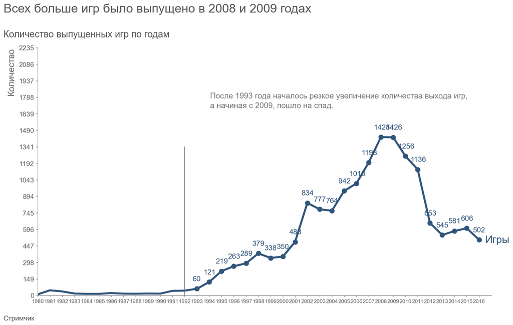

```python
data_graph = pd.pivot_table(df, values=['name'], index=['year_of_release'], aggfunc='count')
data_graph_2 = pd.pivot_table(df, values=['name'], index=['platform'], aggfunc='count')

graph_x = (data_graph.index)
line = [(data_graph['name'])]
gap = [True, 13]
colors = [True, '#30557b']
titles = ['Всех больше игр было выпущено в 2008 и 2009 годах',
          '',
          'Количество выпущенных игр по годам']
y_name = 'Количество'
line_names = ['Игры']
result = 'После 1993 года началось резкое увеличение количества выхода игр, \nа начиная с 2009, пошло на спад.'
year = ' '
data_source = 'Стримчик'

# display((line[0].shape()))
# display(list(x[0]))

create_line(list(graph_x), [list(data_graph['name'])], gap, colors, titles, y_name,  line_names, result, year, data_source)
```

Можно было посмотреть количество уникальных игр, но зачастую игра выходит как временный эксклюзив для одной платформы и выпуск на другую платформу может быть в другой год.

```
31
```

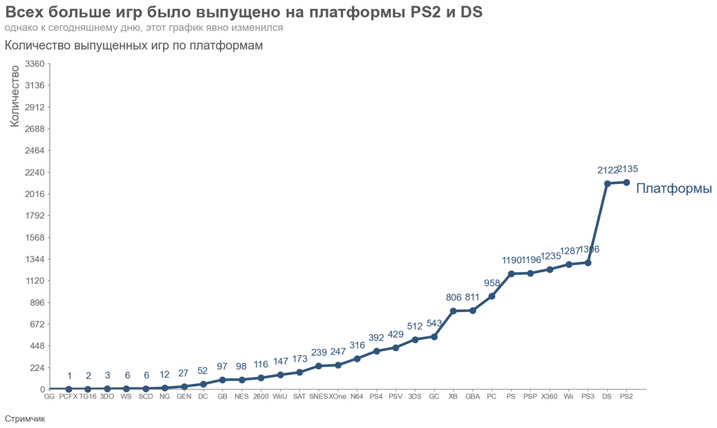

```python
data_graph_2 = pd.pivot_table(df, values=['name'], index=['platform'], aggfunc='count').sort_values('name', ascending=True)
display(len(list(data_graph_2.index)))
title_1 = '$\\bf{Всех\ больше\ игр\ было\ выпущено\ на\ платформы\ PS2\ и\ DS}$'
title_2 = 'однако к сегодняшнему дню, этот график явно изменился'
title_3 = 'Количество выпущенных игр по платформам'
titles = [title_1, title_2, title_3]
result = ''

create_line(list(data_graph_2.index), [list(data_graph_2['name'])], gap=[True, 1], colors=[True, '#30557b'], titles=titles, y_name='Количество', line_names=['Платформы'], result='', year=' ', data_source='Стримчик')
```

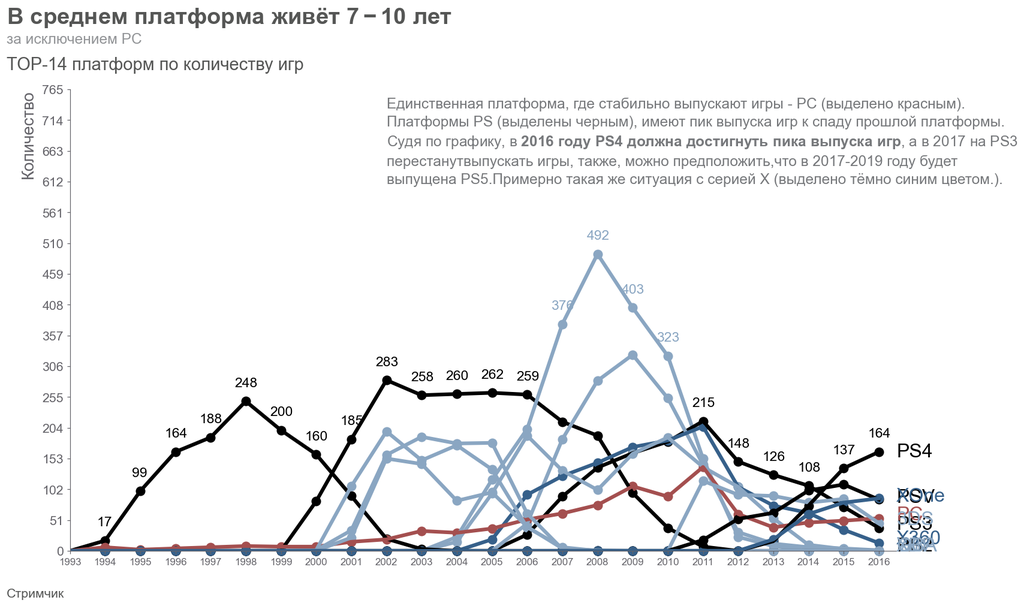

```python
# график
start_year = 1993
end_year = 2017
data = pd.DataFrame(index=range(start_year, end_year), columns=['PS2', 'DS', 'PS3', 'Wii', 'X360', 'PSP', 'PS', 'PC', 'GBA', 'XB', 'GC', '3DS', 'PSV', 'PS4', 'XOne'])
top_games = []
for i in range(len(data.columns)):
    data[data.columns[i]] = pd.pivot_table(df.loc[df['platform'] == data.columns[i]], values=['name'], index=['year_of_release'], aggfunc='count')
    data[data.columns[i]].fillna(0, inplace=True)
    data[data.columns[i]] = data[data.columns[i]].astype(int)
    top_games.append(list(data[data.columns[i]]))
color_a = '#36608a'
color_b = '#a44f4f'
color_c = '#8aa6c2'
color_d = '#36608a'
color_e = 'k'
colors = [True, color_e, color_c, color_e, color_c, color_a, color_c, color_e, color_b, color_c, color_c, color_c, color_c, color_e, color_e, color_a]
result_top_10 = ('Единственная платформа, где стабильно выпускают игры - PC (выделено красным).\n'
                'Платформы PS (выделены черным), имеют пик выпуска игр к спаду прошлой платформы.\n'
                'Судя по графику, в $\\bf{2016\ году\ PS4\ должна\ достигнуть\ пика\ выпуска\ игр}$, а в 2017 на PS3\nперестанут'
                'выпускать игры, также, можно предположить,что в 2017-2019 году будет\nвыпущена PS5.'
                'Примерно такая же ситуация с серией X (выделено тёмно синим цветом.).\n')
titles = ['$\\bf{В\ среднем\ платформа\ живёт\ 7-10\ лет}$', 'за исключением PC','TOP-14 платформ по количеству игр']
# display(data.T)
create_line(list(data.index), top_games, gap=[False, 5], colors=colors, titles=titles, y_name='Количество', line_names=list(data.columns), result=result_top_10, year=' ', data_source='Стримчик')
```

### Вывод

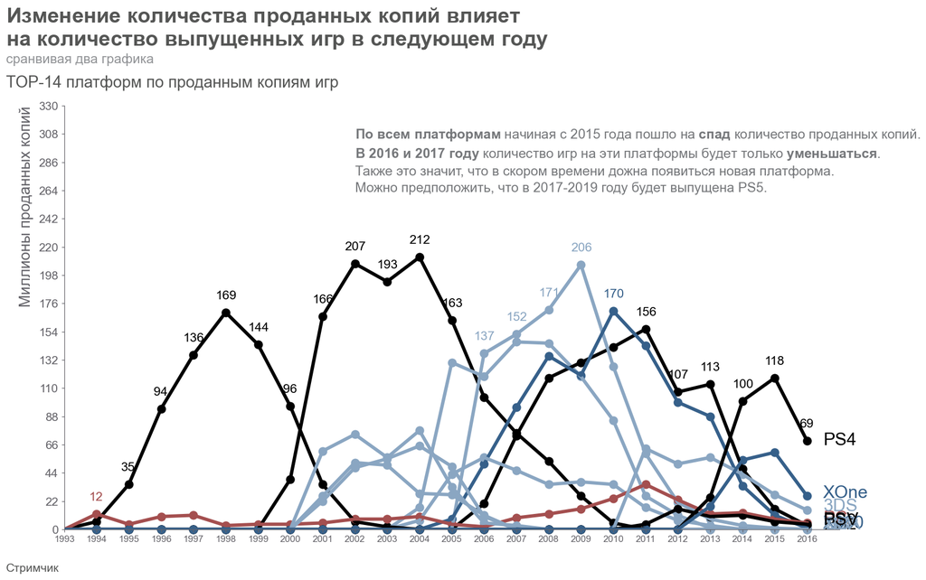

```python
# график
start_year = 1993
end_year = 2017
data_sales = pd.DataFrame(index=range(start_year, end_year), columns=['PS2', 'DS', 'PS3', 'Wii', 'X360', 'PSP', 'PS', 'PC', 'GBA', 'XB', 'GC', '3DS', 'PSV', 'PS4', 'XOne'])
top_sales = []
for i in range(len(data.columns)):
    data_sales[data_sales.columns[i]] = pd.pivot_table(df.loc[df['platform'] == data_sales.columns[i]], values=['sales_sum'], index=['year_of_release'], aggfunc='sum')
    data_sales[data_sales.columns[i]].fillna(0, inplace=True)
    data_sales[data_sales.columns[i]] = data_sales[data_sales.columns[i]].astype(int)
    top_sales.append(list(data_sales[data_sales.columns[i]]))
color_a = '#36608a'
color_b = '#a44f4f'
color_c = '#8aa6c2'
color_d = '#36608a'
color_e = 'k'
colors = [True, color_e, color_c, color_e, color_c, color_a, color_c, color_e, color_b, color_c, color_c, color_c, color_c, color_e, color_e, color_a]
result_sales = ('$\\bf{По\ всем\ платформам}$ начиная с 2015 года пошло на $\\bf{спад}$ количество проданных копий.\n'
                '$\\bf{В\ 2016\ и\ 2017\ году}$ количество игр на эти платформы будет только $\\bf{уменьшаться}$.\n'
                'Также это значит, что в скором времени дожна появиться новая платформа.\n'
                'Можно предположить, что в 2017-2019 году будет выпущена PS5.\n')
titles_sales = [('$\\bf{Изменение\ количества\ проданных\ копий\ влияет}$\n'
                '$\\bf{на\ количество\ выпущенных\ игр\ в\ следующем\ году}$'),
                'сранвивая два графика',
                'TOP-14 платформ по проданным копиям игр']
# display(data.T)
create_line(list(data_sales.index), top_sales, gap=[False, 5], colors=colors, titles=titles_sales, y_name='Миллионы проданных копий', line_names=list(data_sales.columns), result=result_sales, year=' ', data_source='Стримчик')
```

### Вывод

```python
data_sales.sum().sort_values(ascending=False)
```

```
PS2     1242
X360     955
PS3      925
Wii      885
DS       799
PS       723
PS4      312
GBA      309
PSP      286
3DS      255
XB       249
PC       242
GC       194
XOne     158
PSV       51
dtype: int64
```

### 5 Пункт

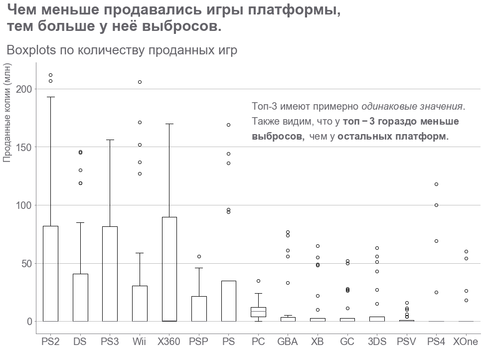

```python
fig, ax = plt.subplots(figsize=(16,10))
fig.suptitle('Чем меньше продавались игры платформы,\nтем больше у неё выбросов.', x=0.075, y=0.96, ha='left', va='bottom')
ax.boxplot(data_sales)
ax.grid(True, axis='y')
ax.set_xticklabels(data_sales.columns)
ax.set_title('Boxplots по количеству проданных игр', position=(-0.066,0.1))
ax.set_ylabel('Проданные копии (млн)', fontsize=18, rotation='vertical', color=gray_dark)
fig.text(0.5, 0.666, ('Топ-3 имеют примерно $\\it{одинаковые\ значения.}$\n'
                      'Также видим, что у $\\bf{топ-3\ гораздо\ меньше}$\n'
                      '$\\bf{выбросов,}$ чем у $\\bf{остальных\ платформ.}$'
                      ), fontsize=20, linespacing=1.4)
plt.show()
```

```python
df.loc[df['platform'] == 'PS2'].head(20)
```

|  | name | platform | year_of_release | genre | na_sales | eu_sales | jp_sales | other_sales | critic_score | user_score | rating | sales_sum |
| --- | --- | --- | --- | --- | --- | --- | --- | --- | --- | --- | --- | --- |
| 17 | Grand Theft Auto: San Andreas | PS2 | 2004 | Action | 9.43 | 0.40 | 0.41 | 10.57 | 95.00 | 9.00 | M | 20.81 |
| 24 | Grand Theft Auto: Vice City | PS2 | 2002 | Action | 8.41 | 5.49 | 0.47 | 1.78 | 95.00 | 8.70 | M | 16.15 |
| 28 | Gran Turismo 3: A-Spec | PS2 | 2001 | Racing | 6.85 | 5.09 | 1.87 | 1.16 | 95.00 | 8.40 | E | 14.97 |
| 38 | Grand Theft Auto III | PS2 | 2001 | Action | 6.99 | 4.51 | 0.30 | 1.30 | 97.00 | 8.50 | M | 13.10 |
| 48 | Gran Turismo 4 | PS2 | 2004 | Racing | 3.01 | 0.01 | 1.10 | 7.53 | 89.00 | 8.50 | E | 11.65 |
| 84 | Final Fantasy X | PS2 | 2001 | Role-Playing | 2.91 | 2.07 | 2.73 | 0.33 | 92.00 | 8.70 | T | 8.04 |
| 102 | Need for Speed Underground | PS2 | 2003 | Racing | 3.27 | 2.83 | 0.08 | 1.02 | 85.00 | 8.60 | E | 7.20 |
| 113 | Need for Speed Underground 2 | PS2 | 2004 | Racing | 2.71 | 3.02 | 0.08 | 1.09 | 82.00 | 8.60 | E | 6.90 |
| 114 | Medal of Honor: Frontline | PS2 | 2002 | Shooter | 2.93 | 2.75 | 0.17 | 0.99 | 88.00 | 8.50 | T | 6.84 |
| 132 | Kingdom Hearts | PS2 | 2002 | Role-Playing | 3.64 | 1.20 | 1.49 | 0.07 | 85.00 | 8.80 | E | 6.40 |
| 144 | Metal Gear Solid 2: Sons of Liberty | PS2 | 2001 | Action | 2.45 | 2.01 | 0.87 | 0.72 | 96.00 | 8.70 | M | 6.05 |
| 148 | Final Fantasy XII | PS2 | 2006 | Role-Playing | 1.88 | 0.00 | 2.33 | 1.74 | 92.00 | 7.60 | T | 5.95 |
| 169 | Crash Bandicoot: The Wrath of Cortex | PS2 | 2001 | Platform | 2.07 | 2.29 | 0.24 | 0.82 | 66.00 | 7.10 | E | 5.42 |
| 177 | Final Fantasy X-2 | PS2 | 2003 | Role-Playing | 1.92 | 1.08 | 2.11 | 0.17 | 85.00 | 6.60 | T | 5.28 |
| 183 | Madden NFL 2004 | PS2 | 2003 | Sports | 4.26 | 0.26 | 0.01 | 0.71 | 94.00 | 8.50 | E | 5.24 |
| 186 | Dragon Quest VIII: Journey of the Cursed King | PS2 | 2004 | Role-Playing | 0.65 | 0.75 | 3.61 | 0.20 | 89.00 | 8.80 | T | 5.21 |
| 193 | Medal of Honor: Rising Sun | PS2 | 2003 | Shooter | 1.98 | 2.23 | 0.13 | 0.80 | 68.00 | 7.60 | T | 5.14 |
| 196 | Guitar Hero II | PS2 | 2006 | Misc | 3.81 | 0.63 | 0.00 | 0.68 | 92.00 | 8.50 | T | 5.12 |
| 208 | Guitar Hero III: Legends of Rock | PS2 | 2007 | Misc | 3.49 | 0.01 | 0.01 | 1.48 | 82.00 | 8.20 | T | 4.99 |
| 213 | Madden NFL 06 | PS2 | 2005 | Sports | 3.98 | 0.26 | 0.01 | 0.66 | 88.00 | 8.00 | E | 4.91 |

```python
df['user_score'].replace({0:np.nan}, inplace=True)
df['critic_score'].replace({0:np.nan}, inplace=True)
```

### 6-7 пункты

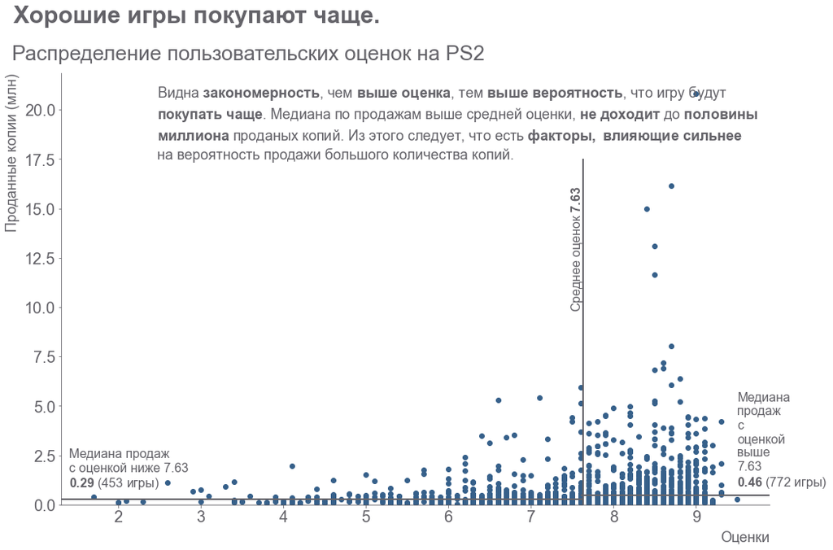

```python
mean_score = df.loc[df['platform'] == 'PS2']['user_score'].mean()
median_sale_more_8 = df.loc[(df['platform'] == 'PS2') & (df['user_score'] >= mean_score)]['sales_sum'].median()
count_sale_more_8 = df.loc[(df['platform'] == 'PS2') & (df['user_score'] >= mean_score)]['sales_sum'].count()
median_sale_less_8 = df.loc[(df['platform'] == 'PS2') & (df['user_score'] < mean_score)]['sales_sum'].median()
count_sale_less_8 = df.loc[(df['platform'] == 'PS2') & (df['user_score'] < mean_score)]['sales_sum'].count()
fig, ax = plt.subplots()
fig.suptitle('Хорошие игры покупают чаще.', x=0.073, y=0.96, ha='left', va='bottom')
ax.set_title('Распределение пользовательских оценок на PS2', position=(-0.07,0.1))
ax.scatter(x=df.loc[df['platform'] == 'PS2']['user_score'], y=df.loc[df['platform'] == 'PS2']['sales_sum'])
fig.text(0.23, 0.73, ('Видна $\\bf{закономерность}$, чем $\\bf{выше\ оценка}$, тем $\\bf{выше\ вероятность}$, что игру будут\n$\\bf{покупать\ чаще}$. '
                      'Медиана по продажам выше средней оценки, $\\bf{не\ доходит}$ до $\\bf{половины}$\n$\\bf{миллиона}$ проданых копий. '
                      'Из этого следует, что есть $\\bf{факторы,\ влияющие\ сильнее}$\nна вероятность продажи большого количества копий.'
                      ), fontsize=18, linespacing=1.3)
ax.text(9.5, median_sale_more_8+0.5, f'Медиана\nпродаж\nс\nоценкой\nвыше\n{round(mean_score, 2)}\n$\\bf{round(median_sale_more_8, 2)}$ ({count_sale_more_8} игры)', fontsize='16')
ax.text(1.4, median_sale_less_8+0.6, f'Медиана продаж\nс оценкой ниже {round(mean_score, 2)}\n$\\bf{round(median_sale_less_8, 2)}$ ({count_sale_less_8} игры)', fontsize='16')
ax.text(mean_score-0.16, 10, f'Среднее оценок $\\bf{round(mean_score, 2)}$', fontsize='16', rotation='vertical')
ax.axvline(x=mean_score, ymax=0.8,  lw=2, color=gray_dark)
ax.axhline(y=median_sale_more_8, xmin=0.735, lw=2, color=gray_dark)
ax.axhline(y=median_sale_less_8, xmax=0.735, lw=2, color=gray_dark)
ax.set_ylabel('Проданные копии (млн)', fontsize=18, rotation='vertical', color=gray_dark)
ax.set_xlabel('Оценки', fontsize=18, color=gray_dark)
ax.set_ylim(0, ax.get_ylim()[1])

plt.show()
```

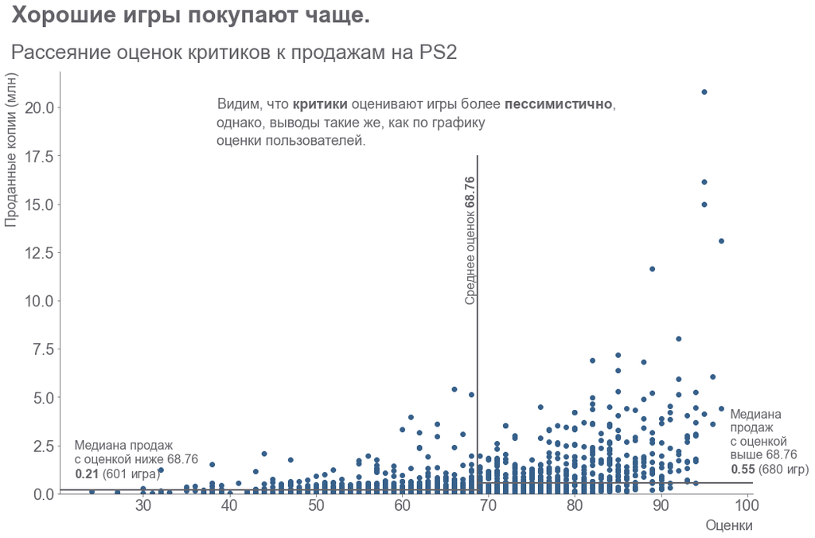

```python
mean_score = df.loc[df['platform'] == 'PS2']['critic_score'].mean()
median_sale_more_8 = df.loc[(df['platform'] == 'PS2') & (df['critic_score'] >= mean_score)]['sales_sum'].median()
count_sale_more_8 = df.loc[(df['platform'] == 'PS2') & (df['critic_score'] >= mean_score)]['sales_sum'].count()
count_sale_less_8 = df.loc[(df['platform'] == 'PS2') & (df['critic_score'] < mean_score)]['sales_sum'].count()
median_sale_less_8 = df.loc[(df['platform'] == 'PS2') & (df['critic_score'] < mean_score)]['sales_sum'].median()
fig, ax = plt.subplots()
fig.suptitle('Хорошие игры покупают чаще.', x=0.071, y=0.96, ha='left', va='bottom')
ax.set_title('Рассеяние оценок критиков к продажам на PS2', position=(-0.071,0.1))
ax.scatter(x=df.loc[df['platform'] == 'PS2']['critic_score'], y=df.loc[df['platform'] == 'PS2']['sales_sum'])
fig.text(0.3, 0.75, ('Видим, что $\\bf{критики}$ оценивают игры более $\\bf{пессимистично}$,\nоднако, выводы такие же, как по графику\nоценки пользователей.'
                      ), fontsize=18, linespacing=1.3)
ax.text(98, median_sale_more_8+0.5, f'Медиана\nпродаж\nс оценкой\nвыше {round(mean_score, 2)}\n$\\bf{round(median_sale_more_8, 2)}$ ({count_sale_more_8} игр)', fontsize='16')
ax.text(22, median_sale_less_8+0.6, f'Медиана продаж\nс оценкой ниже {round(mean_score, 2)}\n$\\bf{round(median_sale_less_8, 2)}$ ({count_sale_less_8} игра)', fontsize='16')
ax.text(mean_score-1.6, 10, f'Среднее оценок $\\bf{round(mean_score, 2)}$', fontsize='16', rotation='vertical')
ax.axvline(x=mean_score, ymax=0.8,  lw=2, color=gray_dark)
ax.axhline(y=median_sale_more_8, xmin=0.605, lw=2, color=gray_dark)
ax.axhline(y=median_sale_less_8, xmax=0.605, lw=2, color=gray_dark)
ax.set_ylabel('Проданные копии (млн)', fontsize=18, rotation='vertical', color=gray_dark)
ax.set_xlabel('Оценки', fontsize=18, color=gray_dark)
ax.set_ylim(0, ax.get_ylim()[1])

plt.show()
```

```python
df.loc[df['platform'] == 'PS2'].corr()
```

|  | year_of_release | na_sales | eu_sales | jp_sales | other_sales | critic_score | user_score | sales_sum |
| --- | --- | --- | --- | --- | --- | --- | --- | --- |
| year_of_release | 1.00 | -0.15 | -0.21 | -0.10 | 0.01 | -0.10 | -0.10 | -0.16 |
| na_sales | -0.15 | 1.00 | 0.65 | 0.20 | 0.57 | 0.40 | 0.17 | 0.92 |
| eu_sales | -0.21 | 0.65 | 1.00 | 0.22 | 0.31 | 0.30 | 0.12 | 0.78 |
| jp_sales | -0.10 | 0.20 | 0.22 | 1.00 | 0.18 | 0.22 | 0.15 | 0.40 |
| other_sales | 0.01 | 0.57 | 0.31 | 0.18 | 1.00 | 0.21 | 0.07 | 0.71 |
| critic_score | -0.10 | 0.40 | 0.30 | 0.22 | 0.21 | 1.00 | 0.56 | 0.40 |
| user_score | -0.10 | 0.17 | 0.12 | 0.15 | 0.07 | 0.56 | 1.00 | 0.17 |
| sales_sum | -0.16 | 0.92 | 0.78 | 0.40 | 0.71 | 0.40 | 0.17 | 1.00 |

```python
df.loc[df['platform'] == 'X360'].corr()
```

|  | year_of_release | na_sales | eu_sales | jp_sales | other_sales | critic_score | user_score | sales_sum |
| --- | --- | --- | --- | --- | --- | --- | --- | --- |
| year_of_release | 1.00 | -0.01 | 0.05 | -0.13 | -0.00 | -0.01 | -0.23 | 0.00 |
| na_sales | -0.01 | 1.00 | 0.85 | 0.49 | 0.96 | 0.38 | 0.11 | 0.98 |
| eu_sales | 0.05 | 0.85 | 1.00 | 0.46 | 0.95 | 0.38 | 0.11 | 0.93 |
| jp_sales | -0.13 | 0.49 | 0.46 | 1.00 | 0.50 | 0.28 | 0.18 | 0.51 |
| other_sales | -0.00 | 0.96 | 0.95 | 0.50 | 1.00 | 0.40 | 0.12 | 0.99 |
| critic_score | -0.01 | 0.38 | 0.38 | 0.28 | 0.40 | 1.00 | 0.62 | 0.39 |
| user_score | -0.23 | 0.11 | 0.11 | 0.18 | 0.12 | 0.62 | 1.00 | 0.11 |
| sales_sum | 0.00 | 0.98 | 0.93 | 0.51 | 0.99 | 0.39 | 0.11 | 1.00 |

```python
df.loc[df['platform'] == 'PS3'].corr()
```

|  | year_of_release | na_sales | eu_sales | jp_sales | other_sales | critic_score | user_score | sales_sum |
| --- | --- | --- | --- | --- | --- | --- | --- | --- |
| year_of_release | 1.00 | -0.15 | -0.07 | 0.05 | -0.09 | -0.00 | -0.13 | -0.10 |
| na_sales | -0.15 | 1.00 | 0.81 | 0.34 | 0.87 | 0.45 | 0.14 | 0.94 |
| eu_sales | -0.07 | 0.81 | 1.00 | 0.37 | 0.97 | 0.38 | 0.09 | 0.96 |
| jp_sales | 0.05 | 0.34 | 0.37 | 1.00 | 0.38 | 0.20 | 0.17 | 0.46 |
| other_sales | -0.09 | 0.87 | 0.97 | 0.38 | 1.00 | 0.39 | 0.11 | 0.98 |
| critic_score | -0.00 | 0.45 | 0.38 | 0.20 | 0.39 | 1.00 | 0.63 | 0.43 |
| user_score | -0.13 | 0.14 | 0.09 | 0.17 | 0.11 | 0.63 | 1.00 | 0.13 |
| sales_sum | -0.10 | 0.94 | 0.96 | 0.46 | 0.98 | 0.43 | 0.13 | 1.00 |

### Вывод

На мой взгляд, нельзя сказать, что оценки и продажи сильно взаимосвязаны. Большие значения продаж на больших значениях оценок больше похожи на выбросы, чем на что-то закономерное.  
Корреляции показываают, что отношение между оценками критиков и продажами сильнее, чем отношение между оценками пользователей и продажами. Думаю, это связано с тем, что критики более критично относятся к продуктам.  
В сравнении, платформы PS2, X360 и PS3 не сильно отличаются в корреляции между оценкой и продажами.

### 8 пункт

```python
df
```

|  | name | platform | year_of_release | genre | na_sales | eu_sales | jp_sales | other_sales | critic_score | user_score | rating | sales_sum |
| --- | --- | --- | --- | --- | --- | --- | --- | --- | --- | --- | --- | --- |
| 0 | Wii Sports | Wii | 2006 | Sports | 41.36 | 28.96 | 3.77 | 8.45 | 76.00 | 8.00 | E | 82.54 |
| 1 | Super Mario Bros. | NES | 1985 | Platform | 29.08 | 3.58 | 6.81 | 0.77 | NaN | NaN | 0 | 40.24 |
| 2 | Mario Kart Wii | Wii | 2008 | Racing | 15.68 | 12.76 | 3.79 | 3.29 | 82.00 | 8.30 | E | 35.52 |
| 3 | Wii Sports Resort | Wii | 2009 | Sports | 15.61 | 10.93 | 3.28 | 2.95 | 80.00 | 8.00 | E | 32.77 |
| 4 | Pokemon Red/Pokemon Blue | GB | 1996 | Role-Playing | 11.27 | 8.89 | 10.22 | 1.00 | NaN | NaN | 0 | 31.38 |
| ... | ... | ... | ... | ... | ... | ... | ... | ... | ... | ... | ... | ... |
| 16710 | Samurai Warriors: Sanada Maru | PS3 | 2016 | Action | 0.00 | 0.00 | 0.01 | 0.00 | NaN | NaN | 0 | 0.01 |
| 16711 | LMA Manager 2007 | X360 | 2006 | Sports | 0.00 | 0.01 | 0.00 | 0.00 | NaN | NaN | 0 | 0.01 |
| 16712 | Haitaka no Psychedelica | PSV | 2016 | Adventure | 0.00 | 0.00 | 0.01 | 0.00 | NaN | NaN | 0 | 0.01 |
| 16713 | Spirits & Spells | GBA | 2003 | Platform | 0.01 | 0.00 | 0.00 | 0.00 | NaN | NaN | 0 | 0.01 |
| 16714 | Winning Post 8 2016 | PSV | 2016 | Simulation | 0.00 | 0.00 | 0.01 | 0.00 | NaN | NaN | 0 | 0.01 |

16465 rows × 12 columns

[figure not shown]

```python
df_pivot_genre = df.loc[df['year_of_release'] > 2011].pivot_table(values='sales_sum', index='genre', aggfunc=['count', 'sum']).droplevel(axis=1, level=1).sort_values('count', ascending=False)
df_sales = df_pivot_genre['sum'].astype(int)
df_genre = df_pivot_genre['count']
fig, ax = plt.subplots()
for i in range(len(df_sales)):
    color = [gray_dark,blue_dark, gray_light, blue_light]
    k = 1
    if i > 2:
        k = 0
    ax.bar(df_sales.index[i], df_sales[i], 0.4, color=color[k+2], align='edge')
    ax.bar(df_genre.index[i], df_genre[i], -0.4, color=color[k], align='edge')
fig.suptitle('Action - самый выпускаемый и продаваемый жанр игр', x=0.066, y=0.96, ha='left', va='bottom')
ax.set_title('Количество выпущенных и проданных игр по жанрам', position=(-0.076,0.1))
ax.set_ylabel('Количество игр', fontsize=18, rotation='vertical', color=gray_dark)
ax.set_xlabel('Жанры', fontsize=18, color=gray_dark)
ax.set_xticklabels(df_sales.index, fontsize=14)
ax.set_ylim(0, ax.get_ylim()[1])
fig.text(0.28, 0.6, ('В последние 5 лет, самыми выпускаемыми и продаваемыми жанрами были Aсtion И RPG.\n'
                    'Из интересного можем заметить, что жанр Adventure не интересен публике, \n'
                    'а жанр Shooter набирает обороты по продажам, несмотря на то, \n'
                    'что игр выпускается относительно мало'), fontsize=18, linespacing=1.3)
for i in range(len(df_sales)):
    ax.annotate(f'$\\bf{df_sales[i]}$', (ax.get_xticks()[i], df_sales[i]), fontsize=18, ha='left', va='bottom')
    ax.annotate(f'$\\bf{df_genre[i]}$', (ax.get_xticks()[i], df_genre[i]), fontsize=18, ha='right', va='bottom')
plt.show()
```

```python
df.loc[df['genre'] == 'Action'].sort_values('sales_sum', ascending=False).head(20)
```

|  | name | platform | year_of_release | genre | na_sales | eu_sales | jp_sales | other_sales | critic_score | user_score | rating | sales_sum |
| --- | --- | --- | --- | --- | --- | --- | --- | --- | --- | --- | --- | --- |
| 16 | Grand Theft Auto V | PS3 | 2013 | Action | 7.02 | 9.09 | 0.98 | 3.96 | 97.00 | 8.20 | M | 21.05 |
| 17 | Grand Theft Auto: San Andreas | PS2 | 2004 | Action | 9.43 | 0.40 | 0.41 | 10.57 | 95.00 | 9.00 | M | 20.81 |
| 23 | Grand Theft Auto V | X360 | 2013 | Action | 9.66 | 5.14 | 0.06 | 1.41 | 97.00 | 8.10 | M | 16.27 |
| 24 | Grand Theft Auto: Vice City | PS2 | 2002 | Action | 8.41 | 5.49 | 0.47 | 1.78 | 95.00 | 8.70 | M | 16.15 |
| 38 | Grand Theft Auto III | PS2 | 2001 | Action | 6.99 | 4.51 | 0.30 | 1.30 | 97.00 | 8.50 | M | 13.10 |
| 42 | Grand Theft Auto V | PS4 | 2014 | Action | 3.96 | 6.31 | 0.38 | 1.97 | 97.00 | 8.30 | M | 12.62 |
| 46 | Pokemon HeartGold/Pokemon SoulSilver | DS | 2009 | Action | 4.34 | 2.71 | 3.96 | 0.76 | NaN | NaN | 0 | 11.77 |
| 51 | Grand Theft Auto IV | X360 | 2008 | Action | 6.76 | 3.07 | 0.14 | 1.03 | 98.00 | 7.90 | M | 11.00 |
| 57 | Grand Theft Auto IV | PS3 | 2008 | Action | 4.76 | 3.69 | 0.44 | 1.61 | 98.00 | 7.50 | M | 10.50 |
| 81 | FIFA Soccer 13 | PS3 | 2012 | Action | 1.06 | 5.01 | 0.13 | 1.97 | 88.00 | 6.60 | E | 8.17 |
| 91 | Grand Theft Auto: Liberty City Stories | PSP | 2005 | Action | 2.90 | 2.81 | 0.24 | 1.73 | 88.00 | 7.60 | M | 7.68 |
| 93 | The Legend of Zelda: Ocarina of Time | N64 | 1998 | Action | 4.10 | 1.89 | 1.45 | 0.16 | NaN | NaN | 0 | 7.60 |
| 107 | The Legend of Zelda: Twilight Princess | Wii | 2006 | Action | 3.74 | 2.14 | 0.60 | 0.68 | 95.00 | 9.00 | T | 7.16 |
| 118 | Uncharted 3: Drake's Deception | PS3 | 2011 | Action | 2.77 | 2.75 | 0.19 | 1.03 | 92.00 | 8.30 | T | 6.74 |
| 121 | Uncharted 2: Among Thieves | PS3 | 2009 | Action | 3.27 | 2.20 | 0.21 | 0.98 | 96.00 | 8.80 | T | 6.66 |
| 124 | The Legend of Zelda | NES | 1986 | Action | 3.74 | 0.93 | 1.69 | 0.14 | NaN | NaN | 0 | 6.50 |
| 125 | Red Dead Redemption | PS3 | 2010 | Action | 2.79 | 2.53 | 0.17 | 0.99 | 95.00 | 8.80 | M | 6.48 |
| 127 | Assassin's Creed III | PS3 | 2012 | Action | 2.64 | 2.52 | 0.16 | 1.12 | 85.00 | 6.90 | M | 6.44 |
| 135 | Red Dead Redemption | X360 | 2010 | Action | 3.70 | 1.95 | 0.09 | 0.58 | 95.00 | 9.00 | M | 6.32 |
| 139 | Driver | PS | 1999 | Action | 3.11 | 2.80 | 0.02 | 0.33 | 87.00 | 8.10 | T | 6.26 |

```python
df_boxplot_genre = df.loc[df['year_of_release'] > 2011].pivot_table(index='year_of_release', columns='genre', values='sales_sum')
```

```python
df_boxplot_genre
```

| genre year_of_release | Action | Adventure | Fighting | Misc | Platform | Puzzle | Racing | Role-Playing | Shooter | Simulation | Sports | Strategy |
| --- | --- | --- | --- | --- | --- | --- | --- | --- | --- | --- | --- | --- |
| 2012 | 0.45 | 0.10 | 0.32 | 0.60 | 1.67 | 0.16 | 0.45 | 0.60 | 1.49 | 0.74 | 0.56 | 0.22 |
| 2013 | 0.83 | 0.10 | 0.35 | 0.60 | 0.68 | 0.32 | 0.77 | 0.63 | 1.05 | 0.48 | 0.78 | 0.32 |
| 2014 | 0.52 | 0.07 | 0.69 | 0.56 | 0.88 | 0.21 | 0.62 | 0.51 | 1.39 | 0.51 | 0.84 | 0.12 |
| 2015 | 0.28 | 0.15 | 0.38 | 0.30 | 0.47 | 0.12 | 0.45 | 0.48 | 1.99 | 0.38 | 0.69 | 0.12 |
| 2016 | 0.17 | 0.07 | 0.28 | 0.08 | 0.22 | 0.01 | 0.12 | 0.34 | 0.81 | 0.11 | 0.49 | 0.09 |

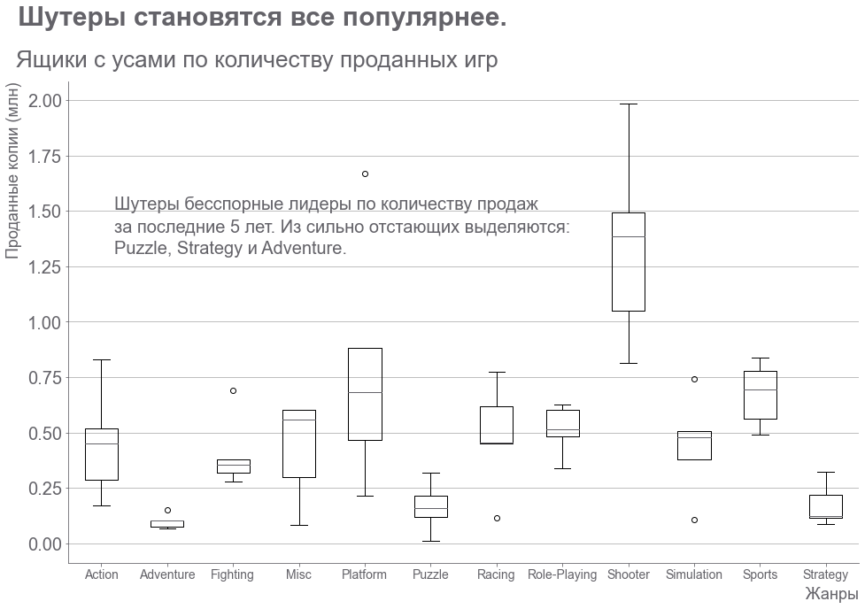

```python
fig, ax = plt.subplots(figsize=(16,10))
fig.suptitle('Шутеры становятся все популярнее.', x=0.075, y=0.96, ha='left', va='bottom')
ax.boxplot(df_boxplot_genre)
ax.grid(True, axis='y')
ax.set_xticklabels(df_boxplot_genre.columns, fontsize=14)
ax.set_title('Ящики с усами по количеству проданных игр', position=(-0.066,0.1))
ax.set_ylabel('Проданные копии (млн)', fontsize=18, rotation='vertical', color=gray_dark)
ax.set_xlabel('Жанры', fontsize=18, color=gray_dark)
fig.text(0.17, 0.61, ('Шутеры бесспорные лидеры по количеству продаж\n'
                      'за последние 5 лет. Из сильно отстающих выделяются: \n'
                      'Puzzle, Strategy и Adventure.'
                      ), fontsize=20, linespacing=1.4)
plt.show()
```

### Чек-лист (ответить на вопросы)

- 1) Сколько игр выпускалось в разные года и важны ли эти данные?
- 2) Как менялись продажи по платформам? выбрать платформы с наибольшими суммарным продажами и построить распределение о годам. За какой срок появляются новые и исчезают старые платформы?
- 3) Выбрать актуальный период, который позволить составить прогноз на 2017 год, при это, не учитывать данные за предыдущие годы.
- 4) Какие платформы лидируют по продажам, растут или падают? выберите несколько потенциально прибыльных платформ.
- 5) Постройте график «ящик с усами» по глобальным продажам игр в разбивке по платформам. Опишите результат.
- 6) Посмотрите, как влияют на продажи внутри одной популярной платформы отзывы пользователей и критиков. Постройте диаграмму рассеяния и посчитайте корреляцию между отзывами и продажами. Сформулируйте выводы..
- 7) Соотнесите выводы с продажами игр на других платформах.
- 8) Посмотрите на общее распределение игр по жанрам. Что можно сказать о самых прибыльных жанрах? Выделяются ли жанры с высокими и низкими продажами?

### Вывод по анализу данных

Очень мало данных, которые помогли бы предсказать развитие игровой индустрии на 2017 год. Данные между собой практически не связаны и не коррелируют. На мой взгляд, единственное что можно сказать исходя из этих данных, что в скором времени будет будет анонсирована следующая платформа серии PlayStation, по другим популярным компаниям выпускающих приставки (Nintendo, Microsoft) сложно что-то говорить.

Если говорить о жанрах и оценке, то в обязательном порядке нужно учитывать хотя бы репутацию линейки игры и производителя игры. К сожалению, из данных которые есть, можно предположить только то, что игры с хорошими оценками лучше продаются, хорошим играм ставят хорошие оценки, а хорошие продажи игры, обеспечат в будущем качество следующей игры. В итоге получается взаимосвязанный круг, который по-большому счету ни о чем полезном сказать не может, так как мы даже не можем посмотреть на игры, где искуственно занижены или завышены оценки.

## Составить портрет пользователя

```python
df.head()
```

|  | name | platform | year_of_release | genre | na_sales | eu_sales | jp_sales | other_sales | critic_score | user_score | rating | sales_sum |
| --- | --- | --- | --- | --- | --- | --- | --- | --- | --- | --- | --- | --- |
| 0 | Wii Sports | Wii | 2006 | Sports | 41.36 | 28.96 | 3.77 | 8.45 | 76.00 | 8.00 | E | 82.54 |
| 1 | Super Mario Bros. | NES | 1985 | Platform | 29.08 | 3.58 | 6.81 | 0.77 | NaN | NaN | 0 | 40.24 |
| 2 | Mario Kart Wii | Wii | 2008 | Racing | 15.68 | 12.76 | 3.79 | 3.29 | 82.00 | 8.30 | E | 35.52 |
| 3 | Wii Sports Resort | Wii | 2009 | Sports | 15.61 | 10.93 | 3.28 | 2.95 | 80.00 | 8.00 | E | 32.77 |
| 4 | Pokemon Red/Pokemon Blue | GB | 1996 | Role-Playing | 11.27 | 8.89 | 10.22 | 1.00 | NaN | NaN | 0 | 31.38 |

```python
df_pivot_platform = df.loc[df['year_of_release'] > 1993].pivot_table(values=['na_sales', 'eu_sales', 'jp_sales', 'other_sales'], index='platform', aggfunc='sum').sort_values('na_sales',ascending=False)
df_sales_eu = df_pivot_platform.loc[df_pivot_platform['eu_sales'] > 212]['eu_sales'].sort_values(ascending=False)
df_sales_na = df_pivot_platform.loc[df_pivot_platform['na_sales'] > 370]['na_sales'].sort_values(ascending=False)
df_sales_jp = df_pivot_platform.loc[df_pivot_platform['jp_sales'] > 77]['jp_sales'].sort_values(ascending=False)
df_sales_ot = df_pivot_platform.loc[df_pivot_platform['other_sales'] > 50]['other_sales'].sort_values(ascending=False)
# df_genre = df_pivot_genre['count']
df_sales_all = [df_sales_na,df_sales_eu,df_sales_jp,df_sales_ot]
df_sakes = pd.DataFrame(data=df_sales_all)
```

```python
df_sakes
```

| platform | X360 | PS2 | Wii | PS3 | DS | PS | 3DS |
| --- | --- | --- | --- | --- | --- | --- | --- |
| na_sales | 596.28 | 580.71 | 487.30 | 390.13 | 380.32 | NaN | NaN |
| eu_sales | 268.37 | 337.32 | 258.32 | 327.21 | NaN | 212.39 | NaN |
| jp_sales | NaN | 137.63 | NaN | 79.41 | 175.00 | 139.78 | 100.62 |
| other_sales | 84.92 | 192.46 | 77.75 | 134.59 | 59.04 | NaN | NaN |

[figure not shown]

```python
fig, ax = plt.subplots()
fig.suptitle('В Северной Америке игры покупают чаще,\nчем в остальных регионах вместевзятых', x=0.071, y=0.96, ha='left', va='bottom')
bars = []
colors = ['#174A7E', '#4A81BF', '#94B2D7', '#BFBEBE', '#555655', '#76787B', '#929497']
values = df_sakes.columns
n = df_sakes.shape[0]
ind = np.arange(n)
width = 0.12
for i in range(df_sakes.shape[1]):
    bars.append(ax.bar(ind+width*i, df_sakes[values[i]], width, label=values[i], color=colors[i]))
    ax.bar_label(bars[i], [values[i], values[i], values[i], values[i]], label_type='edge', color='#555655', padding=2, fontsize=14)

ax.set_xticks(ind+width*((len(bars)-1)/2))
ax.set_xticklabels(['North America', 'Europe', 'Japan', 'Other'])
ax.set_title('Продано игр по регионам', position=(-0.071,0.1))
ax.set_ylabel('Количество игр', fontsize=18, rotation='vertical', color=gray_dark)
ax.set_xlabel('Регионы', fontsize=18, color=gray_dark)
ax.set_ylim(0, ax.get_ylim()[1])
fig.text(0.4, 0.70, ('В $\\bf{Японии}$ доля продаж c американских платформ $\\bf{не\ попала}$ в топ-5.\n'
                    'В $\\bf{Северной\ Америке}$, наоборот, $\\bf{самая\ популярная}$ платформа $\\bf{X360}$.\n'
                    'На момент конца 2016 года, можно было с уверенностью сказать, что\n'
                    '$\\bf{PS2}$ самая популярная платформа $\\bf{в\ мире}$'), fontsize=18, linespacing=1.3)
# ax.legend(fontsize=18, bbox_to_anchor=(0.98, 0.98), title='Платформы')
plt.show()
```

```python
columns_genre = ['na_sales', 'eu_sales', 'jp_sales', 'other_sales']
df_genre_sales = df.pivot_table(index='genre', values=columns_genre, aggfunc='sum')
index_genre = df_genre_sales.index
df_genre_sales.reset_index(inplace=True)
for j in range(4):
    df_genre_sales.sort_values(columns_genre[j], ascending=False, inplace=True, ignore_index=True)
    for i in range(5, len(index_genre)):
        df_genre_sales[columns_genre[j]][i] = 0
df_genre_sales.set_index('genre', inplace=True)
df_genre_sales.replace({0:np.nan}, inplace=True)
df_genre_sales.dropna(how='all', inplace=True)
df_genre_sales = df_genre_sales.reindex(columns=columns_genre, copy=False)
display(df_genre_sales)
```

| genre | na_sales | eu_sales | jp_sales | other_sales |
| --- | --- | --- | --- | --- |
| Action | 863.23 | 511.24 | 160.14 | 182.26 |
| Sports | 679.80 | 375.06 | 135.25 | 133.97 |
| Shooter | 584.83 | 314.52 | NaN | 103.33 |
| Racing | NaN | 234.99 | NaN | 75.68 |
| Misc | 399.57 | 210.60 | 107.02 | 73.10 |
| Role-Playing | NaN | NaN | 353.39 | NaN |
| Platform | 444.44 | NaN | 130.71 | NaN |

```python
df_genre_sales.iloc[6]
```

```
na_sales      444.44
eu_sales         NaN
jp_sales      130.71
other_sales      NaN
Name: Platform, dtype: float64
```

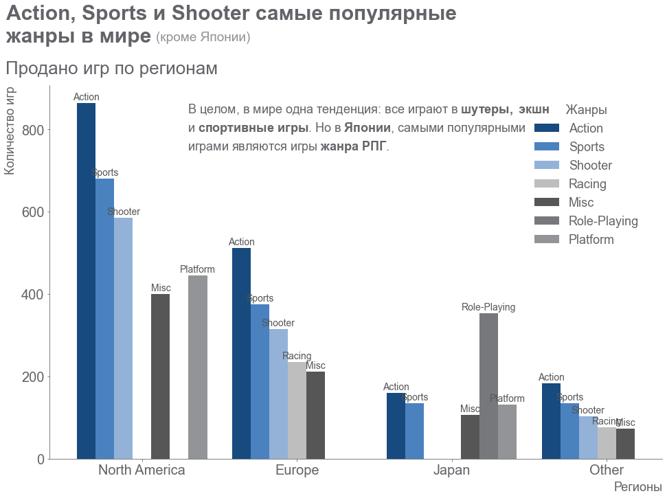

```python
fig, ax = plt.subplots()
fig.suptitle('Action, Sports и Shooter самые популярные\nжанры в мире ', x=0.071, y=0.96, ha='left', va='bottom')
bars = []
colors = ['#174A7E', '#4A81BF', '#94B2D7', '#BFBEBE', '#555655', '#76787B', '#929497']
values_columns = df_genre_sales.columns
values_index = df_genre_sales.index
n = df_genre_sales.shape[1]
ind = np.arange(n)
width = 0.12
for i in range(df_genre_sales.shape[0]):
    bars.append(ax.bar(ind+width*i, df_genre_sales.iloc[i], width, label=values_index[i], color=colors[i]))
    ax.bar_label(bars[i], [values_index[i], values_index[i], values_index[i], values_index[i]], label_type='edge', color='#555655', padding=2, fontsize=14)

ax.set_xticks(ind+width*((len(bars)-1)/2))
ax.set_xticklabels(['North America', 'Europe', 'Japan', 'Other'])
ax.set_title('Продано игр по регионам', position=(-0.071,0.1))
ax.set_ylabel('Количество игр', fontsize=18, rotation='vertical', color=gray_dark)
ax.set_xlabel('Регионы', fontsize=18, color=gray_dark)
ax.set_ylim(0, ax.get_ylim()[1])
fig.text(0.3, 0.75, ('В целом, в мире одна тенденция: все играют в $\\bf{шутеры,\ экшн}$\n'
                    'и $\\bf{спортивные\ игры}$. Но в $\\bf{Японии}$, самыми популярными\nиграми являются игры $\\bf{жанра\ РПГ}$.'), fontsize=18, linespacing=1.3)
fig.text(0.26, 0.97, ('(кроме Японии)'), fontsize=19, linespacing=1.3, alpha=0.7)
ax.legend(fontsize=18, bbox_to_anchor=(0.98, 0.98), title='Жанры')
plt.show()
```

```python
df['rating'].unique()
```

```
array(['E', 0, 'M', 'T', 'E10+', 'K-A', 'AO', 'EC', 'RP'], dtype=object)
```

```python
columns_rating = ['na_sales', 'eu_sales', 'jp_sales', 'other_sales']
df_rating = df.pivot_table(values=columns_rating, index='rating', aggfunc='sum')
df_rating = df_rating.reindex(columns_rating, axis='columns')
# df_rating.drop([0], inplace=True)
```

[figure not shown]

```python
fig, ax = plt.subplots()
fig.suptitle('Распределение проданных игр по рейтингу не зависит от региона', x=0.071, y=0.96, ha='left', va='bottom')
bars = []
colors = ['#174A7E', '#4A81BF', '#94B2D7', '#BFBEBE', '#555655', '#76787B', '#929497', 'k', 'b']
values_columns = df_rating.columns
values_index = df_rating.index
n = df_rating.shape[1]
ind = np.arange(n)
width = 0.09

for i in range(df_rating.shape[0]):
    bars.append(ax.bar(ind+width*i, df_rating.iloc[i], width, label=values_index[i], color=colors[i]))
    ax.bar_label(bars[i], [values_index[i], values_index[i], values_index[i], values_index[i]], label_type='edge', color='#555655', padding=2, fontsize=14)

ax.set_xticks(ind+width*((len(bars)-1)/2))
ax.set_xticklabels(['North America', 'Europe', 'Japan', 'Other'])
ax.legend(fontsize=18, bbox_to_anchor=(0.98, 0.8), title='Рейтинг')
ax.set_title('Проданные игры в зависимости от рейтинга', position=(-0.071,0.1))
ax.set_ylabel('Количество игр', fontsize=18, rotation='vertical', color=gray_dark)
ax.set_xlabel('Регионы', fontsize=18, color=gray_dark)
ax.set_ylim(0, ax.get_ylim()[1])
fig.text(0.3, 0.75, ('Основная аудитория игр - подростки от 13 лет и старше.\n'
                    'Также видим, что множество игр без рейтинга.\n'
                    'В Европе и Японии это может быть связано с другими системами рейтингов.\n'
                    'Не могу определить, почему в Северной Америке тоже такая ситуация.'), fontsize=18, linespacing=1.3)
plt.show()
```

### Чек-лист (ответить на вопросы)

#### Определить для пользователя каждого региона (NA, EU, JP)

- 1) Самые популярные платформы (топ-5). Описать различия в долях продаж.
- 2) Самые популярные жанры (топ-5). Пояснить разницу.
- 3) Влияет ли рейтинг ESRB на продажи в отдельном регионе?

## Проверка гипотез

Для того, чтобы сравнить присатвочные платформы и персональный компьютер, возьмём одну из самых популярных консолей от компании Microsoft - Xbox One

### Первая гипотеза

Нулевая гипотеза: средние пользовательские рейтинги платформ Xbox One и PC одинаковые  
Альтернативная гипотеза: средние пользовательские рейтинги платформ Xbox One и PC различаются

```python
df.head()
```

|  | name | platform | year_of_release | genre | na_sales | eu_sales | jp_sales | other_sales | critic_score | user_score | rating | sales_sum |
| --- | --- | --- | --- | --- | --- | --- | --- | --- | --- | --- | --- | --- |
| 0 | Wii Sports | Wii | 2006 | Sports | 41.36 | 28.96 | 3.77 | 8.45 | 76.00 | 8.00 | E | 82.54 |
| 1 | Super Mario Bros. | NES | 1985 | Platform | 29.08 | 3.58 | 6.81 | 0.77 | NaN | NaN | 0 | 40.24 |
| 2 | Mario Kart Wii | Wii | 2008 | Racing | 15.68 | 12.76 | 3.79 | 3.29 | 82.00 | 8.30 | E | 35.52 |
| 3 | Wii Sports Resort | Wii | 2009 | Sports | 15.61 | 10.93 | 3.28 | 2.95 | 80.00 | 8.00 | E | 32.77 |
| 4 | Pokemon Red/Pokemon Blue | GB | 1996 | Role-Playing | 11.27 | 8.89 | 10.22 | 1.00 | NaN | NaN | 0 | 31.38 |

```python
alpha = .05
df_hyp_01_xbox = df.loc[(df['platform'] == 'XOne') & (df['year_of_release'] > 2011)]['user_score'].dropna()
df_hyp_01_pc = df.loc[(df['platform'] == 'PC') & (df['year_of_release'] > 2011)]['user_score'].dropna()
results_p = st.ttest_ind(df_hyp_01_xbox, df_hyp_01_pc)
p_value = results_p.pvalue
print('p-value = {:.3%}'.format(p_value))
if (p_value < alpha):
    print("Отвергаем нулевую гипотезу")
else:
    print("Не отвергаем нулевую гипотезу")
```

```
p-value = 59.702%
Не отвергаем нулевую гипотезу
```

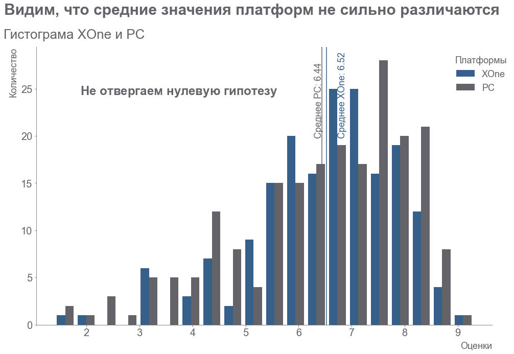

```python
fig, ax = plt.subplots()
fig.suptitle('Видим, что средние значения платформ не сильно различаются', x=0.071, y=0.96, ha='left', va='bottom')
ax.hist([df_hyp_01_xbox, df_hyp_01_pc], label=['XOne', 'PC'], bins=20)
ax.set_title('Гистограма XOne и PC', position=(-0.071,0.1))
ax.set_ylabel('Количество', fontsize=18, rotation='vertical', color=gray_dark)
ax.set_xlabel('Оценки', fontsize=18, color=gray_dark)
ax.set_ylim(0, ax.get_ylim()[1])
fig.text(0.2, 0.75, ('$\\bf{Не\ отвергаем\ нулевую\ гипотезу}$'), fontsize=24, linespacing=1.3)
ax.axvline(df_hyp_01_xbox.mean(), color=blue_dark)
ax.axvline(df_hyp_01_pc.mean(), color=gray_dark)
ax.text(6.29, 20,f'Среднее PC: {round(df_hyp_01_pc.mean(), 2)}', fontsize=18, rotation='vertical',color=gray_dark)
ax.text(6.74, 20,f'Среднее XOne: {round(df_hyp_01_xbox.mean(), 2)}', fontsize=18, rotation='vertical',color=blue_dark)
ax.legend(fontsize=18, bbox_to_anchor=(0.9, 0.999), title='Платформы')
plt.show()
```

### Вторая гипотеза

Можем посмотреть виляение жанров на оценки. Возьмём самые популярные жанры.

Нулевая гипотеза: Средние пользовательские рейтинги жанров Action (англ. «действие», экшен-игры) и Sports (англ. «спортивные соревнования») одинаковые.  
Альтернативаня гипотеза: Средние пользовательские рейтинги жанров Action (англ. «действие», экшен-игры) и Sports (англ. «спортивные соревнования») разные.

```python
alpha = .05
df_hyp_02_act = df.loc[(df['genre'] == 'Action')  & (df['year_of_release'] > 2011)]['user_score'].dropna()
df_hyp_02_spo = df.loc[(df['genre'] == 'Sports')  & (df['year_of_release'] > 2011)]['user_score'].dropna()
results_p = st.ttest_ind(df_hyp_02_act, df_hyp_02_spo)
p_value = results_p.pvalue
print('p-value = {:.3%}'.format(p_value))
if (p_value < alpha):
    print("Отвергаем нулевую гипотезу")
else:
    print("Не отвергаем нулевую гипотезу")
```

```
p-value = 0.000%
Отвергаем нулевую гипотезу
```

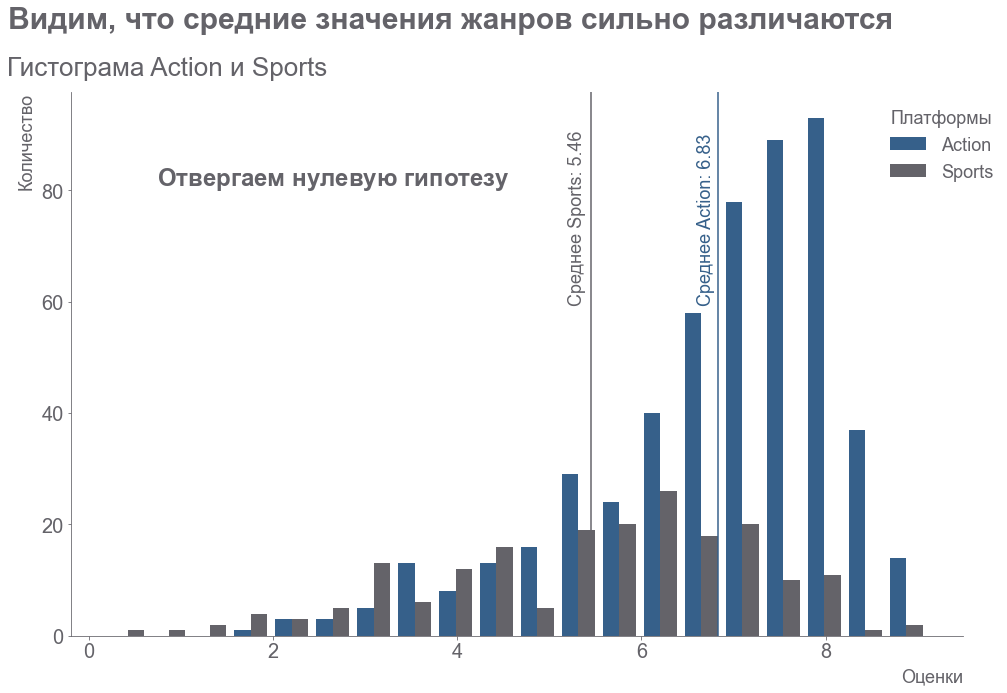

```python
fig, ax = plt.subplots()
fig.suptitle('Видим, что средние значения жанров сильно различаются', x=0.071, y=0.96, ha='left', va='bottom')
ax.hist([df_hyp_02_act, df_hyp_02_spo], label=['Action', 'Sports'], bins=20)
ax.set_title('Гистограма Action и Sports', position=(-0.071,0.1))
ax.set_ylabel('Количество', fontsize=18, rotation='vertical', color=gray_dark)
ax.set_xlabel('Оценки', fontsize=18, color=gray_dark)
ax.set_ylim(0, ax.get_ylim()[1])
fig.text(0.2, 0.75, ('$\\bf{Отвергаем\ нулевую\ гипотезу}$'), fontsize=24, linespacing=1.3)
ax.axvline(df_hyp_02_act.mean(), color=blue_dark)
ax.axvline(df_hyp_02_spo.mean(), color=gray_dark)
ax.text(6.60, 60,f'Среднее Action: {round(df_hyp_02_act.mean(), 2)}', fontsize=18, rotation='vertical',color=blue_dark)
ax.text(5.2, 60,f'Среднее Sports: {round(df_hyp_02_spo.mean(), 2)}', fontsize=18, rotation='vertical',color=gray_dark)
ax.legend(fontsize=18, bbox_to_anchor=(0.9, 0.999), title='Платформы')
plt.show()
```

### Вывод по гипотезам

1) У платформ XOne и PC близкие друг к друг оценки.  
2) Игры жанра Action больше нравятся пользователям, чем игры жанра Sport.

# Общий вывод

## Анализ данных

Увидели "жизнь" разных платформ. Узнали, что игровые платформы живут 8+/-2 года.  
Рост игровой игровой идустрии начался с 1993 года, судя по данным, с появлением на рынке PS1. Однако, по моему детскому опыту, на NES и SEGA было немало игр, но в данных они практически не отражались.

К сожалению, исходя из данных мы практически ничего не можем предположить на 2017 год.

1. В течении 1-2 годов прекратиться выпуск игр на платформу PS3.
2. В скором времени должен состояться анонс PS5.
3. На PC так и будут +/- стабильно выходить одно количество игр не падая и не поднимаясь.
4. Экшены, РПГ, шутеры, спортивные игры более продаваемые чем остальные жанры, однако, на рынке экшен-игр более 10% продаж обеспечивает компания Rockstar с сериям GTA и Red Dead Redemption, а в спортивных играх продажи делают Fifa и Pes. Из этого можно предположить, что нужны дополнительные показатели для анализа.

## Портрет пользователя

Исходя из данных, большинство пользователей препочитают либо семейство PS, либо семейство Xbox.  
Из жанров предпочитают Экшн, РПГ, Шутеры и Спортивные.

## Вывод по проекту

Проанализировав имеющиеся даные, я пришёл к выводу, что шаги предложенные в проекте не отвечают на изначальный вопрос "Выявить определяющие успешность игры закономерности. Это позволит сделать ставку на потенциально популярный продукт и спланировать рекламные кампании."  
Чтобы ответить на этот вопрос, если смотреть на данные поверхностно, нужно ставить на выпуск игр определенной компании, либо определенной серии игр (компания Rockstar или серия игр Fallout, к примеру).  
Если анализировать глубже, то нужно анализировать внутренние составляющие игр (качество текстур, сюжет, мир, оптимизация, настроение других популярных игр и т.д.). Это позволит с большей вероятностью предсказывать судьбу игры, чем данные, предоставленные в этом проекте.  
Промежуточный выводы:

1. Шутеры очень популярны, однако не совсем понятно, это новые шутеры популярны или уже зарекомендовавшие себя.
2. Рпг все больше выходит за пределы Японии и становятся популярны в других странах.
3. В каждом популярном жанре есть уникумы, которые составляют большую часть продаж. Из этого можно предположить, что нужно рассматривать не только жанр, но и историю линейки игры, производителя и издателя.

Общий промежуточный вывод: продавать шутеры, рпг, спортивные игры, экшены, но опираясь на ожидания и реакции на анонсы.